# Présentation de l’application de colSBM sur Doré et al. 2020

## Clustering avec le modèle iid

Avec le modèle *iid* nous obtenons les 5 collections suivantes:

| collection_id | net_id |
| --- | --- |
| 1 | arroyo1982_1+arroyo1982_2+arroyo3 |
| 1 | eberling1999 |
| 1 | kato1990 |
| 1 | petanidou1991 |
| 1 | Junker2013 |
| 1 | bartomeus2008 |
| 1 | Benadi2013_1(950m)+Benadi2013_2(1170m)+Benadi2013_6(2020m) |
| 1 | Benadi2013_4(1700m)+Benadi2013_5(1800m) |
| 1 | Struck1994 |
| 1 | Kato2000 |
| 1 | Albrecht2010_49yr+Albrecht2010_63yr+Albrecht2010_84yr+Albrecht2010_109yr+Albrecht2010_130yr |
| 1 | Baldock2011_TB+Baldock2011_JN |
| 1 | Dattilo2016 |
| 1 | Devoto2005_PP+Devoto2005_AP |
| 1 | Devoto2005_VT |
| 1 | Devoto2005_LL+Devoto2005_CT |
| 1 | Freitas2006 |
| 1 | Gibson2006_TA2 |
| 1 | Jedrzejewska2013_Ochata+Jedrzejewska2013_Kabaty |
| 1 | MonteroCastano2017_Albufera+MonteroCastano2017_Llimpa+MonteroCastano2017_Tirant |
| 1 | Kehinde2014_Joostenberg_Conv+Kehinde2014_Joostenberg_Org+Kehinde2014_Joostenberg_Nat+Kehinde2014_Laibach_Conv+Kehinde2014_Laibach_Org+Kehinde2014_Laibach_Nat+Kehinde2014_Spier_Conv+Kehinde2014_Spier_N… |
| 1 | Pinheiro2008 |
| 1 | Watts2016_Chicon+Watts2016_Mantanay+Watts2016_Choquebamba+Watts2016_Huaran+Watts2016_Piscacucho+Watts2016_Poques+Watts2016_Pumamarca+Watts2016_Tiaparo+Watts2016_Yanacocha |
| 1 | Kato1993 |
| 1 | KatoMiura1996 |
| 1 | Kakutani1990 |
| 1 | Inoue1990 |
| 1 | Fragoso_RA2+Fragoso_RA3+Fragoso_RD1+Fragoso_RD3 |
| 1 | Souza_cerrado |
| 1 | Souza_chaco |
| 1 | Souza_pantanal |
| 1 | Souza_vereda |
| 1 | Adedoja2019 |
| 1 | Oleques2019 |
| 1 | Baldock2019_Bristol |
| 1 | Baldock2019_Edinburgh |
| 1 | Baldock2019_Leeds |
| 1 | Baldock2019_Reading |

| collection_id | net_id |
| --- | --- |
| 2 | dupont2003 |
| 2 | herrera1988 |
| 2 | inouye1988 |
| 2 | medan2002ld |
| 2 | medan2002rb |
| 2 | ramirez1992 |
| 2 | ramirez1989 |
| 2 | Burkle2013 |
| 2 | Olito-Fox2014 |
| 2 | Benadi2013_3(1340m) |
| 2 | Aizen2008_Challhuaco_U+Aizen2008_Challhuaco_D |
| 2 | Aizen2008_Cerro Otto_U+Aizen2008_Cerro Otto_D |
| 2 | Aizen2008_Llao-llao_U+Aizen2008_Llao-llao_D |
| 2 | Chamberlain_cr1+Chamberlain_cr2+Chamberlain_fs1+Chamberlain_fs2+Chamberlain_go1+Chamberlain_go2+Chamberlain_mm1+Chamberlain_mm2+Chamberlain_mz1+Chamberlain_mz2+Chamberlain_sm1+Chamberlain_sm2 |
| 2 | Chamberlain_HLU+Chamberlain_HLG+Chamberlain_OKU+Chamberlain_OKG+Chamberlain_WLU+Chamberlain_WLG+Chamberlain_SOU+Chamberlain_SOG |
| 2 | Devoto2005_LQ |
| 2 | Devoto2005_LT+Devoto2005_LH |
| 2 | LemusJimenez2003 |
| 2 | Lundgren2005 |
| 2 | Marrero2013 |
| 2 | Trojelsgaard2015_La Gomera |
| 2 | Trojelsgaard2015_Gran Canaria |
| 2 | Zackenberg |
| 2 | Yoshihara2008 |
| 2 | Fragoso_RA1+Fragoso_RD2 |
| 2 | PopicThesis |
| 2 | Pornon2017 |
| 2 | Orford_B1+Orford_B2+Orford_B3+Orford_B4+Orford_B5+Orford_B10 |
| 2 | Orford_B6+Orford_B7+Orford_B8+Orford_B9 |
| 2 | Blumel2016 |
| 2 | Kantsa2018 |
| 2 | Bennett2018 |
| 2 | Adedoja2018b_baseZone+Adedoja2018b_MidZone+Adedoja2018b_HighZone+Adedoja2018b_PeakZone |
| 2 | CordenizPicanco2018_NatVeg |
| 2 | CordenizPicanco2018_ExoFor |
| 2 | Benadi2018 |
| 2 | Hackett2019_NZ_salt_marsh+Hackett2019_NZ_sand_dune+Hackett2019_NZ_scrub_coprosma |
| 2 | Jolls2019 |
| 2 | Traveset2013_Fernandina |
| 2 | Traveset2013_Pinta |
| 2 | Traveset2013_Santiago |
| 2 | Traveset2013_SantaCruz |
| 2 | Traveset2013_SanCristobal |
| 2 | Simanonok2014 |
| 2 | Son2019_a1+Son2019_a2+Son2019_a3+Son2019_a4+Son2019_a5+Son2019_a6+Son2019_a7+Son2019_a8+Son2019_F1+Son2019_F2+Son2019_F3+Son2019_F4+Son2019_F5+Son2019_F6+Son2019_F7+Son2019_F8 |

| collection_id | net_id |
| --- | --- |
| 3 | small1976 |

| collection_id | net_id |
| --- | --- |
| 4 | smith-ramirez2005 |
| 4 | Weiner2011 |
| 4 | Kaiser_control+Kaiser_restored |
| 4 | Gilarranz2014_amarante+Gilarranz2014_barrosa+Gilarranz2014_cincocerros+Gilarranz2014_difuntito+Gilarranz2014_difuntos+Gilarranz2014_elmorro+Gilarranz2014_labrava+Gilarranz2014_lachata+Gilarranz2014_la… |
| 4 | Kaiser-Bunbury2017_Bernica+Kaiser-Bunbury2017_Casse-dent+Kaiser-Bunbury2017_Copolia+Kaiser-Bunbury2017_La-Reserve+Kaiser-Bunbury2017_Rosebelle+Kaiser-Bunbury2017_Salazie+Kaiser-Bunbury2017_Tea-Plantat… |
| 4 | Fang2012 |
| 4 | Aizen2008_Puerto Blest_U+Aizen2008_Puerto Blest_D |
| 4 | Chamberlain_Site1+Chamberlain_Site2+Chamberlain_Site3+Chamberlain_Site4+Chamberlain_Site5+Chamberlain_Site6 |
| 4 | Dupont2009_IsenBjerg+Dupont2009_Other |
| 4 | Gibson2006_GA1 |
| 4 | Gibson2006_TA1 |
| 4 | LaraRomero2016_pe?alara_EP+LaraRomero2016_pe?alara_PA+LaraRomero2016_nevero_EP+LaraRomero2016_nevero_PA |
| 4 | Trojelsgaard2015_Tenerife Teno Bajo+Trojelsgaard2015_Tenerife Fasnia |
| 4 | Vanbergen2013_balfarm+Vanbergen2013_bridgend+Vanbergen2013_dalhaikie+Vanbergen2013_netherton+Vanbergen2013_backhill+Vanbergen2013_corntulloch+Vanbergen2013_allancreich |
| 4 | Pfeiffer_CNE+Pfeiffer_CNM+Pfeiffer_CNT+Pfeiffer_CPB+Pfeiffer_CPM+Pfeiffer_CPR+Pfeiffer_CPS+Pfeiffer_M2+Pfeiffer_RP1+Pfeiffer_RP2+Pfeiffer_LM+Pfeiffer_LO+Pfeiffer_BD+Pfeiffer_BH+Pfeiffer_BS |
| 4 | Carstensen_Gigante+Carstensen_Paulino+Carstensen_Tinkerbell+Carstensen_Midway+Carstensen_Cedro+Carstensen_Elefante+Carstensen_Soizig |
| 4 | Welti_ID+Welti_K1B+Welti_K4A+Welti_4B+Welti_20B+Welti_20C+Welti_N1A+Welti_N1B+Welti_N4A+Welti_N4B+Welti_N20A+Welti_N20B |
| 4 | Grass2013_1+Grass2013_2+Grass2013_3+Grass2013_4+Grass2013_5+Grass2013_6+Grass2013_7+Grass2013_8+Grass2013_9+Grass2013_10+Grass2013_11+Grass2013_12+Grass2013_13+Grass2013_14+Grass2013_15+Grass2013_16+G… |
| 4 | Hackett2019_UK_sand_dune+Hackett2019_UK_grassland+Hackett2019_UK_heathland+Hackett2019_UK_woodland+Hackett2019_UK_salt_marsh+Hackett2019_UK_scrub |
| 4 | Neli2014 |

| collection_id | net_id |
| --- | --- |
| 5 | olensen2002aig |
| 5 | olensen2002flo |
| 5 | vazquez2002 |
| 5 | Shay2016 |
| 5 | Gibson2006_GA2 |
| 5 | Gibson2006_SG |
| 5 | Trojelsgaard2015_El Hierro |
| 5 | Trojelsgaard2015_Fuerteventura |
| 5 | Trojelsgaard2015_Western Sahara |
| 5 | Robinson2018 |
| 5 | CordenizPicanco2018_NatFor |
| 5 | CordenizPicanco2018_SemiPast |
| 5 | CordenizPicanco2018_IntPast |
| 5 | Biella2019 |
| 5 | Nel2017 |
| 5 | Villalobos2019 |
| 5 | LaraRomero2019_blanca+LaraRomero2019_rajada+LaraRomero2019_refugio+LaraRomero2019_torre |
| 5 | Ferrero2013 |
| 5 | Sritongchuay2019_near+Sritongchuay2019_far |

Une fois le modèle de collection appliqué nous obtenons les structures suivantes:

```
##
## Pour la collection 1 du modèle *iid*
```

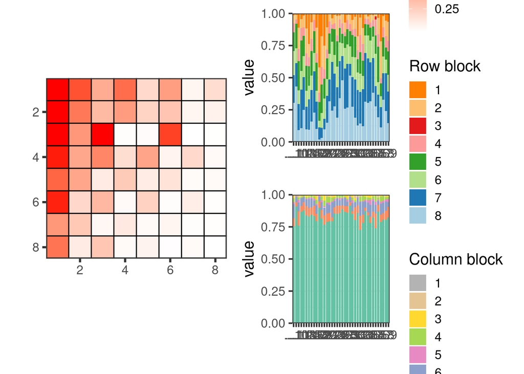

```
##  [1] "arroyo1982_1+arroyo1982_2+arroyo3"
##  [2] "eberling1999"
##  [3] "kato1990"
##  [4] "petanidou1991"
##  [5] "Junker2013"
##  [6] "bartomeus2008"
##  [7] "Benadi2013_1(950m)+Benadi2013_2(1170m)+Benadi2013_6(2020m)"
##  [8] "Benadi2013_4(1700m)+Benadi2013_5(1800m)"
##  [9] "Struck1994"
## [10] "Kato2000"
## [11] "Albrecht2010_49yr+Albrecht2010_63yr+Albrecht2010_84yr+Albrecht2010_109yr+Albrecht2010_130yr"
## [12] "Baldock2011_TB+Baldock2011_JN"
## [13] "Dattilo2016"
## [14] "Devoto2005_PP+Devoto2005_AP"
## [15] "Devoto2005_VT"
```

[output cut: 25 more lines]

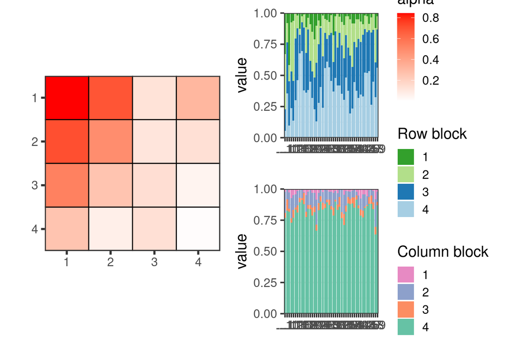

```
##  [1] "dupont2003"
##  [2] "herrera1988"
##  [3] "inouye1988"
##  [4] "medan2002ld"
##  [5] "medan2002rb"
##  [6] "ramirez1992"
##  [7] "ramirez1989"
##  [8] "Burkle2013"
##  [9] "Olito-Fox2014"
## [10] "Benadi2013_3(1340m)"
## [11] "Aizen2008_Challhuaco_U+Aizen2008_Challhuaco_D"
## [12] "Aizen2008_Cerro Otto_U+Aizen2008_Cerro Otto_D"
## [13] "Aizen2008_Llao-llao_U+Aizen2008_Llao-llao_D"
## [14] "Chamberlain_cr1+Chamberlain_cr2+Chamberlain_fs1+Chamberlain_fs2+Chamberlain_go1+Chamberlain_go2+Chamberlain_mm1+Chamberlain_mm2+Chamberlain_mz1+Chamberlain_mz2+Chamberlain_sm1+Chamberlain_sm2"
## [15] "Chamberlain_HLU+Chamberlain_HLG+Chamberlain_OKU+Chamberlain_OKG+Chamberlain_WLU+Chamberlain_WLG+Chamberlain_SOU+Chamberlain_SOG"
```

[output cut: 32 more lines]

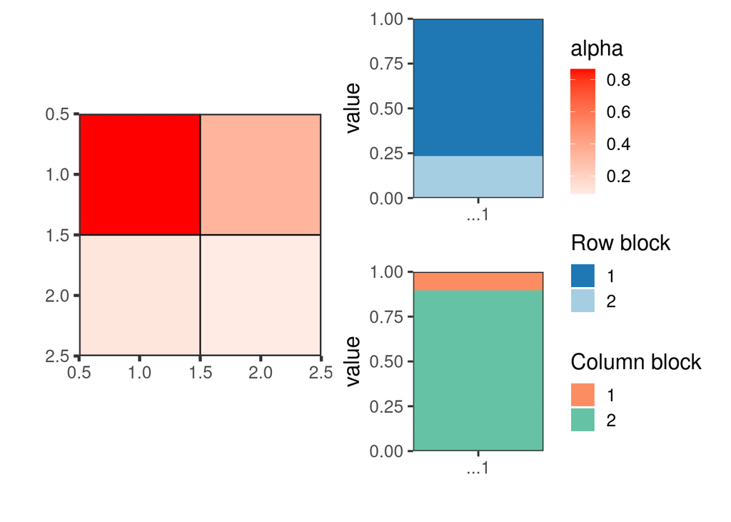

```
## [1] "small1976"
##
## Pour la collection 4 du modèle *iid*
```

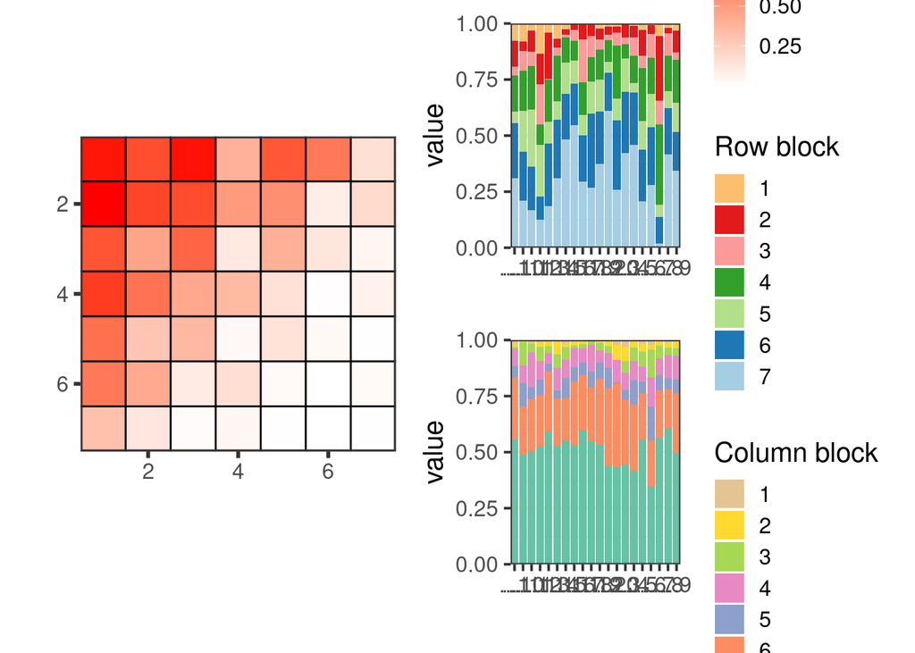

```
##  [1] "smith-ramirez2005"
##  [2] "Weiner2011"
##  [3] "Kaiser_control+Kaiser_restored"
##  [4] "Gilarranz2014_amarante+Gilarranz2014_barrosa+Gilarranz2014_cincocerros+Gilarranz2014_difuntito+Gilarranz2014_difuntos+Gilarranz2014_elmorro+Gilarranz2014_labrava+Gilarranz2014_lachata+Gilarranz2014_lapaja+Gilarranz2014_piedraalta+Gilarranz2014_vigilancia+Gilarranz2014_volcan"
##  [5] "Kaiser-Bunbury2017_Bernica+Kaiser-Bunbury2017_Casse-dent+Kaiser-Bunbury2017_Copolia+Kaiser-Bunbury2017_La-Reserve+Kaiser-Bunbury2017_Rosebelle+Kaiser-Bunbury2017_Salazie+Kaiser-Bunbury2017_Tea-Plantation+Kaiser-Bunbury2017_Trois-Freres"
##  [6] "Fang2012"
##  [7] "Aizen2008_Puerto Blest_U+Aizen2008_Puerto Blest_D"
##  [8] "Chamberlain_Site1+Chamberlain_Site2+Chamberlain_Site3+Chamberlain_Site4+Chamberlain_Site5+Chamberlain_Site6"
##  [9] "Dupont2009_IsenBjerg+Dupont2009_Other"
## [10] "Gibson2006_GA1"
## [11] "Gibson2006_TA1"
## [12] "LaraRomero2016_pe?alara_EP+LaraRomero2016_pe?alara_PA+LaraRomero2016_nevero_EP+LaraRomero2016_nevero_PA"
## [13] "Trojelsgaard2015_Tenerife Teno Bajo+Trojelsgaard2015_Tenerife Fasnia"
## [14] "Vanbergen2013_balfarm+Vanbergen2013_bridgend+Vanbergen2013_dalhaikie+Vanbergen2013_netherton+Vanbergen2013_backhill+Vanbergen2013_corntulloch+Vanbergen2013_allancreich"
## [15] "Pfeiffer_CNE+Pfeiffer_CNM+Pfeiffer_CNT+Pfeiffer_CPB+Pfeiffer_CPM+Pfeiffer_CPR+Pfeiffer_CPS+Pfeiffer_M2+Pfeiffer_RP1+Pfeiffer_RP2+Pfeiffer_LM+Pfeiffer_LO+Pfeiffer_BD+Pfeiffer_BH+Pfeiffer_BS"
## [16] "Carstensen_Gigante+Carstensen_Paulino+Carstensen_Tinkerbell+Carstensen_Midway+Carstensen_Cedro+Carstensen_Elefante+Carstensen_Soizig"
## [17] "Welti_ID+Welti_K1B+Welti_K4A+Welti_4B+Welti_20B+Welti_20C+Welti_N1A+Welti_N1B+Welti_N4A+Welti_N4B+Welti_N20A+Welti_N20B"
## [18] "Grass2013_1+Grass2013_2+Grass2013_3+Grass2013_4+Grass2013_5+Grass2013_6+Grass2013_7+Grass2013_8+Grass2013_9+Grass2013_10+Grass2013_11+Grass2013_12+Grass2013_13+Grass2013_14+Grass2013_15+Grass2013_16+Grass2013_17"
## [19] "Hackett2019_UK_sand_dune+Hackett2019_UK_grassland+Hackett2019_UK_heathland+Hackett2019_UK_woodland+Hackett2019_UK_salt_marsh+Hackett2019_UK_scrub"
## [20] "Neli2014"
##
## Pour la collection 5 du modèle *iid*
```

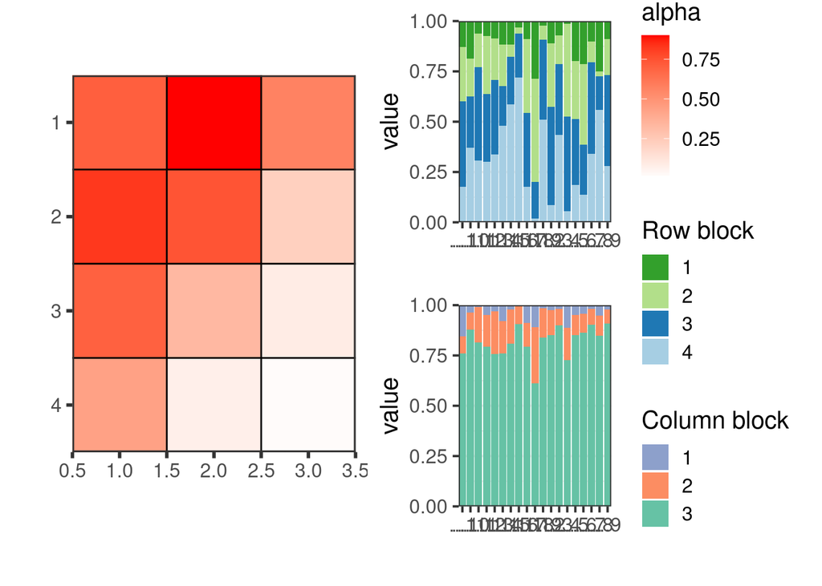

```
##  [1] "olensen2002aig"
##  [2] "olensen2002flo"
##  [3] "vazquez2002"
##  [4] "Shay2016"
##  [5] "Gibson2006_GA2"
##  [6] "Gibson2006_SG"
##  [7] "Trojelsgaard2015_El Hierro"
##  [8] "Trojelsgaard2015_Fuerteventura"
##  [9] "Trojelsgaard2015_Western Sahara"
## [10] "Robinson2018"
## [11] "CordenizPicanco2018_NatFor"
## [12] "CordenizPicanco2018_SemiPast"
## [13] "CordenizPicanco2018_IntPast"
## [14] "Biella2019"
## [15] "Nel2017"
## [16] "Villalobos2019"
## [17] "LaraRomero2019_blanca+LaraRomero2019_rajada+LaraRomero2019_refugio+LaraRomero2019_torre"
## [18] "Ferrero2013"
## [19] "Sritongchuay2019_near+Sritongchuay2019_far"
```

Et voici donc les valeurs numériques pour les $\alpha$ (paramètres de connectivité).

Pour la collection 1 :
$$\begin{bmatrix} 0.00123637715915213 &0.0261430043180643 &0.29545116372612 &0.00832436230485214 &0.103936718909118 &0.0248533395407396 &0.694178880758258 &0.0628624358994011 \\0.002102076856299 &1.1765149145763e-07 &0.999996972807009 &0.886472904950622 &0.527264979162531 &0.0119533610419171 &0.999999371578469 &0.0204149226712038 \\0.00753228339655725 &0.0118878692625895 &0.0408986452894985 &0.0495730368192257 &0.283918853377832 &0.116687609501239 &0.535477994755137 &0.0304518857084774 \\0.0256336634001026 &0.0210113837444109 &0.103179232282131 &0.144651176019806 &0.460055589827639 &0.273800918292412 &0.757283488640965 &0.101049643667939 \\0.0301305628259643 &0.196665701148595 &0.615411098217976 &0.0588884872307517 &0.453496182752643 &0.175182537150115 &0.97423252680414 &0.470982717504111 \\0.177127636061177 &0.049380499352309 &0.427935605005928 &0.501818262672023 &0.834011760647483 &0.725474006249618 &0.999988018981265 &0.199186901521765 \\0.00720265044733079 &0.0930575327403604 &0.370529783987542 &0.0120491541374755 &0.202499804031392 &0.0270744095046821 &0.961800114722099 &0.23508845416808 \\0.0679878806891409 &0.049632358996621 &0.358307012725791 &0.300649291394594 &0.673692396211215 &0.508180986028737 &0.999979291518611 &0.22428882666293 \\ \end{bmatrix}$$
Pour la collection 2 :
$$\begin{bmatrix} 0.0112205970001251 &0.135051528757906 &0.259229579337834 &0.0718112932627616 \\0.316815729584998 &0.125807558979455 &0.843374211328464 &0.694651445844738 \\0.135374596230671 &0.114535693214061 &0.711311497263552 &0.490142164759538 \\0.0477522113175566 &0.144141956436788 &0.538324678535183 &0.261024412794354 \\ \end{bmatrix}$$
Pour la collection 3 :
$$\begin{bmatrix} 0.0885716975353065 &0.111664081599687 \\0.334881013757347 &0.865246043166041 \\ \end{bmatrix}$$
Pour la collection 4 :
$$\begin{bmatrix} 0.661578111613444 &0.161088104215164 &0.79685573208709 &0.964405250230148 &0.393311173261604 &0.958821079802553 &0.828792863729759 \\0.0330153410413152 &0.00550662501425811 &0.145103602349793 &0.353280107227129 &0.0336319293194309 &0.698508114428644 &0.294241109158376 \\0.0869153335905029 &0.18669480940302 &0.557784098090992 &0.834635062296716 &0.50902417933847 &0.977049780095274 &0.858293724693878 \\0.130641975571673 &0.0468664445772688 &0.400076734908099 &0.743540817549902 &0.115228310769126 &0.803232461578049 &0.458372562782068 \\0.00050348524535734 &0.00433364675610269 &0.00472255073543046 &0.0203733118028127 &0.0399245459076273 &0.31591711195424 &0.121544016238656 \\0.00159296482299276 &0.0243466718097033 &0.0263853245340552 &0.104867547515716 &0.165007896800738 &0.657403828133506 &0.43044085519021 \\0.00861343704628633 &0.0730290337982745 &0.152120151857653 &0.440271412183717 &0.348993752058548 &0.886072822130573 &0.685225800660085 \\ \end{bmatrix}$$
Pour la collection 5 :
$$\begin{bmatrix} 0.436121046919647 &0.017347419640313 &0.0737587808012619 &0.825087791446955 \\0.223488417950656 &0.744782643297737 &0.707357259210601 &0.570302618842727 \\0.900319356213034 &0.698402840279341 &0.0915472426135945 &0.330442788848303 \\ \end{bmatrix}$$

## Clustering avec le modèle pi

Avec le modèle *pi* nous obtenons les 2 collections suivantes:

| collection_id | net_id |
| --- | --- |
| 1 | arroyo1982_1+arroyo1982_2+arroyo3 |
| 1 | eberling1999 |
| 1 | inouye1988 |
| 1 | kato1990 |
| 1 | ramirez1992 |
| 1 | petanidou1991 |
| 1 | ramirez1989 |
| 1 | smith-ramirez2005 |
| 1 | Junker2013 |
| 1 | Kaiser_control+Kaiser_restored |
| 1 | bartomeus2008 |
| 1 | Olito-Fox2014 |
| 1 | Benadi2013_1(950m)+Benadi2013_2(1170m)+Benadi2013_6(2020m) |
| 1 | Benadi2013_3(1340m) |
| 1 | Benadi2013_4(1700m)+Benadi2013_5(1800m) |
| 1 | Kaiser-Bunbury2017_Bernica+Kaiser-Bunbury2017_Casse-dent+Kaiser-Bunbury2017_Copolia+Kaiser-Bunbury2017_La-Reserve+Kaiser-Bunbury2017_Rosebelle+Kaiser-Bunbury2017_Salazie+Kaiser-Bunbury2017_Tea-Plantat… |
| 1 | Fang2012 |
| 1 | Shay2016 |
| 1 | Struck1994 |
| 1 | Kato2000 |
| 1 | Aizen2008_Cerro Otto_U+Aizen2008_Cerro Otto_D |
| 1 | Aizen2008_Llao-llao_U+Aizen2008_Llao-llao_D |
| 1 | Aizen2008_Puerto Blest_U+Aizen2008_Puerto Blest_D |
| 1 | Albrecht2010_49yr+Albrecht2010_63yr+Albrecht2010_84yr+Albrecht2010_109yr+Albrecht2010_130yr |
| 1 | Baldock2011_TB+Baldock2011_JN |
| 1 | Chamberlain_cr1+Chamberlain_cr2+Chamberlain_fs1+Chamberlain_fs2+Chamberlain_go1+Chamberlain_go2+Chamberlain_mm1+Chamberlain_mm2+Chamberlain_mz1+Chamberlain_mz2+Chamberlain_sm1+Chamberlain_sm2 |
| 1 | Chamberlain_HLU+Chamberlain_HLG+Chamberlain_OKU+Chamberlain_OKG+Chamberlain_WLU+Chamberlain_WLG+Chamberlain_SOU+Chamberlain_SOG |
| 1 | Chamberlain_Site1+Chamberlain_Site2+Chamberlain_Site3+Chamberlain_Site4+Chamberlain_Site5+Chamberlain_Site6 |
| 1 | Dattilo2016 |
| 1 | Devoto2005_PP+Devoto2005_AP |

[output cut: 54 more lines]

| collection_id | net_id |
| --- | --- |
| 2 | dupont2003 |
| 2 | herrera1988 |
| 2 | medan2002ld |
| 2 | medan2002rb |
| 2 | olensen2002aig |
| 2 | olensen2002flo |
| 2 | small1976 |
| 2 | vazquez2002 |
| 2 | Burkle2013 |
| 2 | Weiner2011 |
| 2 | Gilarranz2014_amarante+Gilarranz2014_barrosa+Gilarranz2014_cincocerros+Gilarranz2014_difuntito+Gilarranz2014_difuntos+Gilarranz2014_elmorro+Gilarranz2014_labrava+Gilarranz2014_lachata+Gilarranz2014_la… |
| 2 | Aizen2008_Challhuaco_U+Aizen2008_Challhuaco_D |
| 2 | Devoto2005_LQ |
| 2 | Devoto2005_LT+Devoto2005_LH |
| 2 | Gibson2006_GA1 |
| 2 | Gibson2006_GA2 |
| 2 | Gibson2006_SG |
| 2 | Lundgren2005 |
| 2 | Trojelsgaard2015_El Hierro |
| 2 | Trojelsgaard2015_Gran Canaria |
| 2 | Trojelsgaard2015_Fuerteventura |
| 2 | Trojelsgaard2015_Western Sahara |
| 2 | Fragoso_RA1+Fragoso_RD2 |
| 2 | Pornon2017 |
| 2 | Kantsa2018 |
| 2 | Robinson2018 |
| 2 | CordenizPicanco2018_NatFor |
| 2 | CordenizPicanco2018_ExoFor |
| 2 | CordenizPicanco2018_SemiPast |
| 2 | CordenizPicanco2018_IntPast |
| 2 | Hackett2019_UK_sand_dune+Hackett2019_UK_grassland+Hackett2019_UK_heathland+Hackett2019_UK_woodland+Hackett2019_UK_salt_marsh+Hackett2019_UK_scrub |
| 2 | Biella2019 |
| 2 | Nel2017 |
| 2 | Villalobos2019 |
| 2 | LaraRomero2019_blanca+LaraRomero2019_rajada+LaraRomero2019_refugio+LaraRomero2019_torre |
| 2 | Traveset2013_Pinta |
| 2 | Ferrero2013 |
| 2 | Neli2014 |
| 2 | Sritongchuay2019_near+Sritongchuay2019_far |

Une fois le modèle de collection appliqué nous obtenons les structures suivantes:

```
##
## Pour la collection 1 du modèle *pi*
```

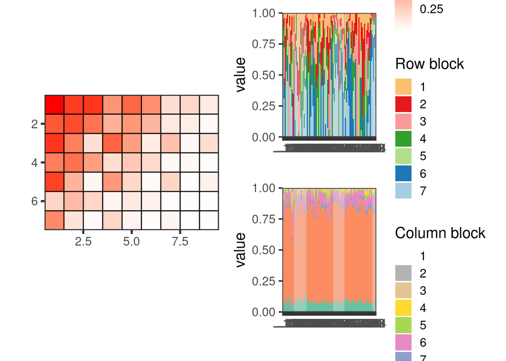

```
##  [1] "arroyo1982_1+arroyo1982_2+arroyo3"
##  [2] "eberling1999"
##  [3] "inouye1988"
##  [4] "kato1990"
##  [5] "ramirez1992"
##  [6] "petanidou1991"
##  [7] "ramirez1989"
##  [8] "smith-ramirez2005"
##  [9] "Junker2013"
## [10] "Kaiser_control+Kaiser_restored"
## [11] "bartomeus2008"
## [12] "Olito-Fox2014"
## [13] "Benadi2013_1(950m)+Benadi2013_2(1170m)+Benadi2013_6(2020m)"
## [14] "Benadi2013_3(1340m)"
## [15] "Benadi2013_4(1700m)+Benadi2013_5(1800m)"
```

[output cut: 71 more lines]

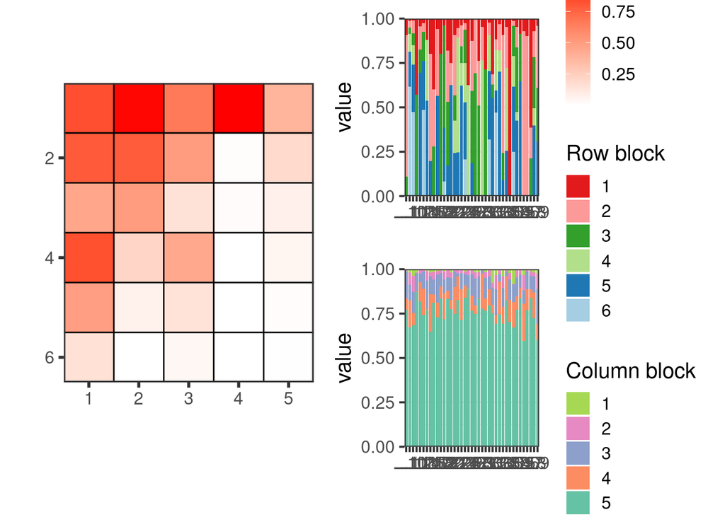

```
##  [1] "dupont2003"
##  [2] "herrera1988"
##  [3] "medan2002ld"
##  [4] "medan2002rb"
##  [5] "olensen2002aig"
##  [6] "olensen2002flo"
##  [7] "small1976"
##  [8] "vazquez2002"
##  [9] "Burkle2013"
## [10] "Weiner2011"
## [11] "Gilarranz2014_amarante+Gilarranz2014_barrosa+Gilarranz2014_cincocerros+Gilarranz2014_difuntito+Gilarranz2014_difuntos+Gilarranz2014_elmorro+Gilarranz2014_labrava+Gilarranz2014_lachata+Gilarranz2014_lapaja+Gilarranz2014_piedraalta+Gilarranz2014_vigilancia+Gilarranz2014_volcan"
## [12] "Aizen2008_Challhuaco_U+Aizen2008_Challhuaco_D"
## [13] "Devoto2005_LQ"
## [14] "Devoto2005_LT+Devoto2005_LH"
## [15] "Gibson2006_GA1"
```

[output cut: 24 more lines]

Et voici donc les valeurs numériques pour les $\alpha$ (paramètres de connectivité).

Pour la collection 1 :
$$\begin{bmatrix} 0.00178000205206004 &0.011712333501692 &0.2076561354918 &0.595377928756984 &0.00688880312294988 &0.148904863477257 &0.0550065933022185 \\0.0231257353492233 &0.0580460428464196 &0.0112690458608419 &0.0696408734977051 &0.0567971672631742 &0.220800368514728 &0.0073904860242255 \\0.351848246377457 &0.0134729460543444 &0.213893240547895 &0.108202306697926 &0.210019591849149 &0.570946546989659 &0.550429062085479 \\0.99950552137064 &0.102316243111456 &0.904930931995163 &0.173962069287596 &0.920212397333916 &0.75185063658045 &0.0357496136544793 \\0.104560197035802 &0.761757968937513 &0.919377903792824 &0.173459551581614 &0.650551411232404 &0.325945346678495 &0.171117992314086 \\0.50147169177676 &0.00849626430731206 &0.0306004944695269 &0.531594575583638 &0.886082828605534 &0.0666860749334997 &0.396374819008027 \\0.21954482495212 &0.045084549450974 &0.204007086130269 &0.0878965957867518 &0.377769498917881 &0.404161048172139 &0.814884754275675 \\0.0292642748773716 &0.860121445476639 &0.118416609497414 &0.697939105178594 &0.535839688710312 &0.0331776556446045 &0.191669486199355 \\0.176421136253882 &0.64999470119768 &0.0119272710288418 &0.714442615102225 &0.0393079135837712 &0.495865654696291 &0.283304245981176 \\ \end{bmatrix}$$
Pour la collection 2 :
$$\begin{bmatrix} 0.00282411251263988 &0.0397060357740951 &0.00181528383160278 &7.37139491515593e-07 &0.158231245516288 &0.189853920804321 \\0.502561551661829 &0.786698068477422 &0.0108341845235787 &0.794127202953188 &0.0146467901136883 &0.145561284334469 \\0.0718072374614855 &4.50894315209366e-05 &0.493807154449413 &0.0776579585223721 &0.152715974108482 &0.508266419328085 \\0.0184079947668994 &0.456558466382895 &0.0485113118174434 &0.44389602530924 &0.215885516099011 &5.48243542870837e-05 \\0.832678697551325 &0.384287576442499 &0.662307823747689 &0.985854257694843 &0.990148625186276 &0.835092303884335 \\ \end{bmatrix}$$

## Clustering avec le modèle rho

| x |
| --- |
| arroyo1982_1+arroyo1982_2+arroyo3 |
| dupont2003 |
| eberling1999 |
| herrera1988 |
| inouye1988 |
| kato1990 |
| medan2002ld |
| medan2002rb |
| olensen2002aig |
| olensen2002flo |
| ramirez1992 |
| small1976 |
| vazquez2002 |
| petanidou1991 |
| ramirez1989 |
| smith-ramirez2005 |
| Burkle2013 |
| Junker2013 |
| Weiner2011 |
| Kaiser_control+Kaiser_restored |
| bartomeus2008 |
| Olito-Fox2014 |
| Gilarranz2014_amarante+Gilarranz2014_barrosa+Gilarranz2014_cincocerros+Gilarranz2014_difuntito+Gilarranz2014_difuntos+Gilarranz2014_elmorro+Gilarranz2014_labrava+Gilarranz2014_lachata+Gilarranz2014_la… |
| Benadi2013_1(950m)+Benadi2013_2(1170m)+Benadi2013_6(2020m) |
| Benadi2013_3(1340m) |
| Benadi2013_4(1700m)+Benadi2013_5(1800m) |
| Kaiser-Bunbury2017_Bernica+Kaiser-Bunbury2017_Casse-dent+Kaiser-Bunbury2017_Copolia+Kaiser-Bunbury2017_La-Reserve+Kaiser-Bunbury2017_Rosebelle+Kaiser-Bunbury2017_Salazie+Kaiser-Bunbury2017_Tea-Plantat… |
| Fang2012 |
| Shay2016 |
| Struck1994 |

[output cut: 93 more lines]

Une fois le modèle de collection appliqué nous obtenons les structures suivantes:

```
##
## Pour la collection 1 du modèle *rho*
```

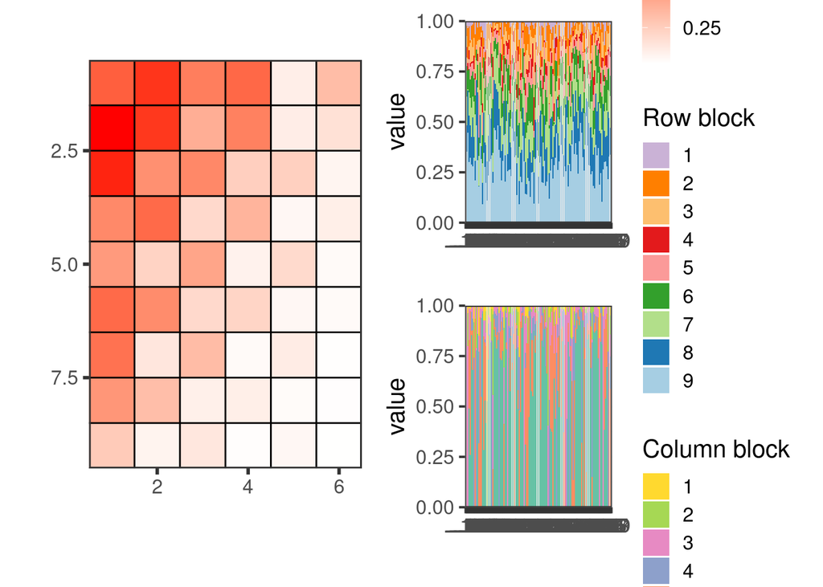

```
##   [1] "arroyo1982_1+arroyo1982_2+arroyo3"
##   [2] "dupont2003"
##   [3] "eberling1999"
##   [4] "herrera1988"
##   [5] "inouye1988"
##   [6] "kato1990"
##   [7] "medan2002ld"
##   [8] "medan2002rb"
##   [9] "olensen2002aig"
##  [10] "olensen2002flo"
##  [11] "ramirez1992"
##  [12] "small1976"
##  [13] "vazquez2002"
##  [14] "petanidou1991"
##  [15] "ramirez1989"
```

[output cut: 108 more lines]

Et voici donc les valeurs numériques pour les $\alpha$ (paramètres de connectivité).

Pour la collection 1:
$$\begin{bmatrix} 0.00699444129121976 &0.0997352340103308 &0.344913127281144 &0.693384464766635 &0.0259645691512376 &0.127624429952597 &0.00194216678903565 &0.0416754490405664 &0.124994596981607 \\0.269470075061936 &0.0108711073556507 &0.0586796278409533 &0.154961599236817 &0.0911614320469805 &0.410917949198091 &0.983210120260713 &0.629341403485269 &0.900962594583753 \\0.337901114308894 &0.0860545405327524 &0.641611909686437 &0.772050855475337 &0.734398674369561 &0.907394629799199 &0.00930017097033338 &0.0213549504625917 &0.0795097182166294 \\0.528393645373521 &0.0851395674015786 &0.332097801206294 &0.0850592301076414 &0.0418876213475229 &0.1938431184467 &0.591969730461658 &0.383191228123897 &0.725528967106269 \\0.0247117584816888 &0.189540598138364 &0.458050478970699 &0.510613323293209 &0.0669492543383874 &0.224456339215804 &0.0530194340543856 &0.23950030453364 &0.596345260069379 \\0.943647234747875 &0.245368793980431 &0.558712316795821 &0.0279112653825249 &0.0400320811509832 &0.195805441714127 &0.727147348712958 &0.216583318180359 &0.57886635581558 \\ \end{bmatrix}$$

## Clustering avec le modèle pirho

Avec le modèle *pirho* nous obtenons les 15 collections suivantes:

| collection_id | net_id |
| --- | --- |
| 1 | arroyo1982_1+arroyo1982_2+arroyo3 |
| 1 | dupont2003 |
| 1 | petanidou1991 |
| 1 | Aizen2008_Challhuaco_U+Aizen2008_Challhuaco_D |
| 1 | Aizen2008_Llao-llao_U+Aizen2008_Llao-llao_D |
| 1 | Jedrzejewska2013_Ochata+Jedrzejewska2013_Kabaty |
| 1 | Pinheiro2008 |
| 1 | Souza_pantanal |
| 1 | Robinson2018 |
| 1 | Jolls2019 |
| 1 | Traveset2013_Fernandina |
| 1 | Baldock2019_Leeds |
| 1 | Baldock2019_Reading |

| collection_id | net_id |
| --- | --- |
| 2 | Benadi2013_3(1340m) |
| 2 | Trojelsgaard2015_La Gomera |
| 2 | CordenizPicanco2018_SemiPast |

| collection_id | net_id |
| --- | --- |
| 3 | Kato2000 |
| 3 | Freitas2006 |
| 3 | Inoue1990 |
| 3 | Souza_cerrado |
| 3 | Adedoja2019 |
| 3 | Baldock2019_Bristol |

| collection_id | net_id |
| --- | --- |
| 4 | Aizen2008_Puerto Blest_U+Aizen2008_Puerto Blest_D |
| 4 | LemusJimenez2003 |

| collection_id | net_id |
| --- | --- |
| 5 | inouye1988 |
| 5 | Junker2013 |
| 5 | Kehinde2014_Joostenberg_Conv+Kehinde2014_Joostenberg_Org+Kehinde2014_Joostenberg_Nat+Kehinde2014_Laibach_Conv+Kehinde2014_Laibach_Org+Kehinde2014_Laibach_Nat+Kehinde2014_Spier_Conv+Kehinde2014_Spier_N… |
| 5 | Watts2016_Chicon+Watts2016_Mantanay+Watts2016_Choquebamba+Watts2016_Huaran+Watts2016_Piscacucho+Watts2016_Poques+Watts2016_Pumamarca+Watts2016_Tiaparo+Watts2016_Yanacocha |
| 5 | Kakutani1990 |
| 5 | Fragoso_RA1+Fragoso_RD2 |
| 5 | Souza_chaco |
| 5 | Oleques2019 |

| collection_id | net_id |
| --- | --- |
| 6 | medan2002ld |
| 6 | small1976 |
| 6 | smith-ramirez2005 |
| 6 | Benadi2013_1(950m)+Benadi2013_2(1170m)+Benadi2013_6(2020m) |
| 6 | Shay2016 |
| 6 | Aizen2008_Cerro Otto_U+Aizen2008_Cerro Otto_D |
| 6 | Lundgren2005 |
| 6 | Zackenberg |
| 6 | Carstensen_Gigante+Carstensen_Paulino+Carstensen_Tinkerbell+Carstensen_Midway+Carstensen_Cedro+Carstensen_Elefante+Carstensen_Soizig |
| 6 | Welti_ID+Welti_K1B+Welti_K4A+Welti_4B+Welti_20B+Welti_20C+Welti_N1A+Welti_N1B+Welti_N4A+Welti_N4B+Welti_N20A+Welti_N20B |
| 6 | Bennett2018 |
| 6 | CordenizPicanco2018_NatFor |
| 6 | CordenizPicanco2018_ExoFor |
| 6 | CordenizPicanco2018_IntPast |
| 6 | Benadi2018 |
| 6 | Villalobos2019 |
| 6 | Traveset2013_Santiago |
| 6 | Traveset2013_SantaCruz |
| 6 | Son2019_a1+Son2019_a2+Son2019_a3+Son2019_a4+Son2019_a5+Son2019_a6+Son2019_a7+Son2019_a8+Son2019_F1+Son2019_F2+Son2019_F3+Son2019_F4+Son2019_F5+Son2019_F6+Son2019_F7+Son2019_F8 |
| 6 | Sritongchuay2019_near+Sritongchuay2019_far |

| collection_id | net_id |
| --- | --- |
| 7 | medan2002rb |
| 7 | olensen2002flo |
| 7 | vazquez2002 |
| 7 | Trojelsgaard2015_Gran Canaria |
| 7 | Trojelsgaard2015_Western Sahara |
| 7 | LaraRomero2019_blanca+LaraRomero2019_rajada+LaraRomero2019_refugio+LaraRomero2019_torre |

| collection_id | net_id |
| --- | --- |
| 8 | Weiner2011 |
| 8 | Kaiser_control+Kaiser_restored |
| 8 | Gilarranz2014_amarante+Gilarranz2014_barrosa+Gilarranz2014_cincocerros+Gilarranz2014_difuntito+Gilarranz2014_difuntos+Gilarranz2014_elmorro+Gilarranz2014_labrava+Gilarranz2014_lachata+Gilarranz2014_la… |
| 8 | Kaiser-Bunbury2017_Bernica+Kaiser-Bunbury2017_Casse-dent+Kaiser-Bunbury2017_Copolia+Kaiser-Bunbury2017_La-Reserve+Kaiser-Bunbury2017_Rosebelle+Kaiser-Bunbury2017_Salazie+Kaiser-Bunbury2017_Tea-Plantat… |
| 8 | Fang2012 |
| 8 | Gibson2006_SG |
| 8 | Gibson2006_TA1 |
| 8 | Trojelsgaard2015_Fuerteventura |
| 8 | Pfeiffer_CNE+Pfeiffer_CNM+Pfeiffer_CNT+Pfeiffer_CPB+Pfeiffer_CPM+Pfeiffer_CPR+Pfeiffer_CPS+Pfeiffer_M2+Pfeiffer_RP1+Pfeiffer_RP2+Pfeiffer_LM+Pfeiffer_LO+Pfeiffer_BD+Pfeiffer_BH+Pfeiffer_BS |
| 8 | Biella2019 |
| 8 | Nel2017 |
| 8 | Ferrero2013 |
| 8 | Neli2014 |

| collection_id | net_id |
| --- | --- |
| 9 | eberling1999 |
| 9 | ramirez1992 |
| 9 | Struck1994 |
| 9 | Albrecht2010_49yr+Albrecht2010_63yr+Albrecht2010_84yr+Albrecht2010_109yr+Albrecht2010_130yr |
| 9 | Devoto2005_PP+Devoto2005_AP |
| 9 | Devoto2005_VT |
| 9 | Gibson2006_TA2 |
| 9 | MonteroCastano2017_Albufera+MonteroCastano2017_Llimpa+MonteroCastano2017_Tirant |
| 9 | Yoshihara2008 |
| 9 | PopicThesis |
| 9 | Orford_B1+Orford_B2+Orford_B3+Orford_B4+Orford_B5+Orford_B10 |
| 9 | Souza_vereda |
| 9 | Adedoja2018b_baseZone+Adedoja2018b_MidZone+Adedoja2018b_HighZone+Adedoja2018b_PeakZone |
| 9 | Hackett2019_NZ_salt_marsh+Hackett2019_NZ_sand_dune+Hackett2019_NZ_scrub_coprosma |

| collection_id | net_id |
| --- | --- |
| 10 | herrera1988 |
| 10 | Burkle2013 |
| 10 | bartomeus2008 |
| 10 | Olito-Fox2014 |
| 10 | Benadi2013_4(1700m)+Benadi2013_5(1800m) |
| 10 | Baldock2011_TB+Baldock2011_JN |
| 10 | Chamberlain_HLU+Chamberlain_HLG+Chamberlain_OKU+Chamberlain_OKG+Chamberlain_WLU+Chamberlain_WLG+Chamberlain_SOU+Chamberlain_SOG |
| 10 | Chamberlain_Site1+Chamberlain_Site2+Chamberlain_Site3+Chamberlain_Site4+Chamberlain_Site5+Chamberlain_Site6 |
| 10 | Devoto2005_LQ |
| 10 | Devoto2005_LT+Devoto2005_LH |
| 10 | Devoto2005_LL+Devoto2005_CT |
| 10 | Dupont2009_IsenBjerg+Dupont2009_Other |
| 10 | Gibson2006_GA1 |
| 10 | LaraRomero2016_pe?alara_EP+LaraRomero2016_pe?alara_PA+LaraRomero2016_nevero_EP+LaraRomero2016_nevero_PA |
| 10 | Marrero2013 |
| 10 | Trojelsgaard2015_Tenerife Teno Bajo+Trojelsgaard2015_Tenerife Fasnia |
| 10 | Vanbergen2013_balfarm+Vanbergen2013_bridgend+Vanbergen2013_dalhaikie+Vanbergen2013_netherton+Vanbergen2013_backhill+Vanbergen2013_corntulloch+Vanbergen2013_allancreich |
| 10 | Fragoso_RA2+Fragoso_RA3+Fragoso_RD1+Fragoso_RD3 |
| 10 | Pornon2017 |
| 10 | Orford_B6+Orford_B7+Orford_B8+Orford_B9 |
| 10 | Blumel2016 |
| 10 | Kantsa2018 |
| 10 | Grass2013_1+Grass2013_2+Grass2013_3+Grass2013_4+Grass2013_5+Grass2013_6+Grass2013_7+Grass2013_8+Grass2013_9+Grass2013_10+Grass2013_11+Grass2013_12+Grass2013_13+Grass2013_14+Grass2013_15+Grass2013_16+G… |
| 10 | CordenizPicanco2018_NatVeg |
| 10 | Hackett2019_UK_sand_dune+Hackett2019_UK_grassland+Hackett2019_UK_heathland+Hackett2019_UK_woodland+Hackett2019_UK_salt_marsh+Hackett2019_UK_scrub |
| 10 | Traveset2013_Pinta |
| 10 | Traveset2013_SanCristobal |
| 10 | Simanonok2014 |
| 10 | Baldock2019_Edinburgh |

| collection_id | net_id |
| --- | --- |
| 11 | kato1990 |
| 11 | ramirez1989 |
| 11 | Kato1993 |

| collection_id | net_id |
| --- | --- |
| 12 | Chamberlain_cr1+Chamberlain_cr2+Chamberlain_fs1+Chamberlain_fs2+Chamberlain_go1+Chamberlain_go2+Chamberlain_mm1+Chamberlain_mm2+Chamberlain_mz1+Chamberlain_mz2+Chamberlain_sm1+Chamberlain_sm2 |
| 12 | Dattilo2016 |
| 12 | KatoMiura1996 |

| collection_id | net_id |
| --- | --- |
| 13 | olensen2002aig |

| collection_id | net_id |
| --- | --- |
| 14 | Trojelsgaard2015_El Hierro |

| collection_id | net_id |
| --- | --- |
| 15 | Gibson2006_GA2 |

Une fois le modèle de collection appliqué nous obtenons les structures suivantes:

```
##
## Pour la collection 1 du modèle *pirho*
```

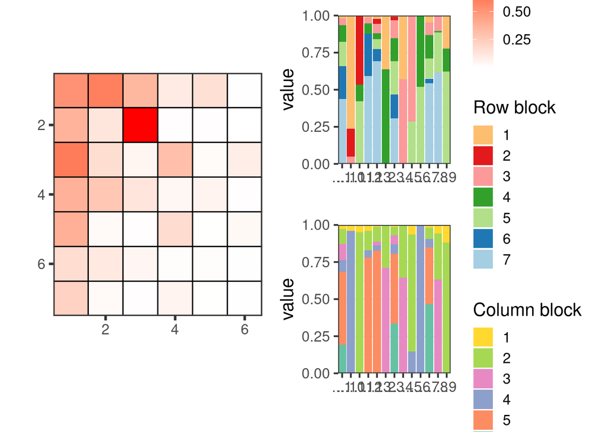

```
##  [1] "arroyo1982_1+arroyo1982_2+arroyo3"
##  [2] "dupont2003"
##  [3] "petanidou1991"
##  [4] "Aizen2008_Challhuaco_U+Aizen2008_Challhuaco_D"
##  [5] "Aizen2008_Llao-llao_U+Aizen2008_Llao-llao_D"
##  [6] "Jedrzejewska2013_Ochata+Jedrzejewska2013_Kabaty"
##  [7] "Pinheiro2008"
##  [8] "Souza_pantanal"
##  [9] "Robinson2018"
## [10] "Jolls2019"
## [11] "Traveset2013_Fernandina"
## [12] "Baldock2019_Leeds"
## [13] "Baldock2019_Reading"
##
## Pour la collection 2 du modèle *pirho*
```

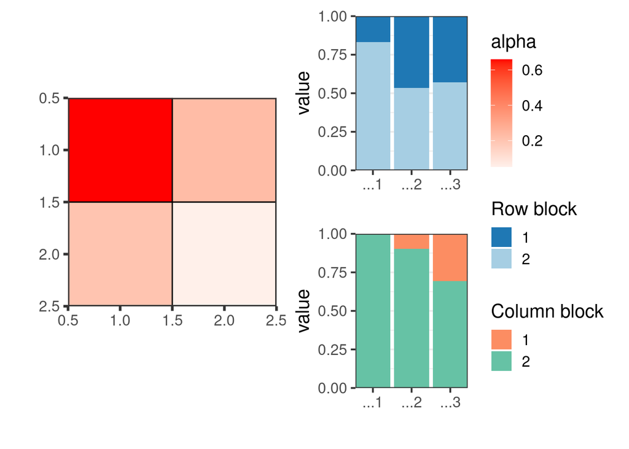

```
## [1] "Benadi2013_3(1340m)"          "Trojelsgaard2015_La Gomera"
## [3] "CordenizPicanco2018_SemiPast"
##
## Pour la collection 3 du modèle *pirho*
```

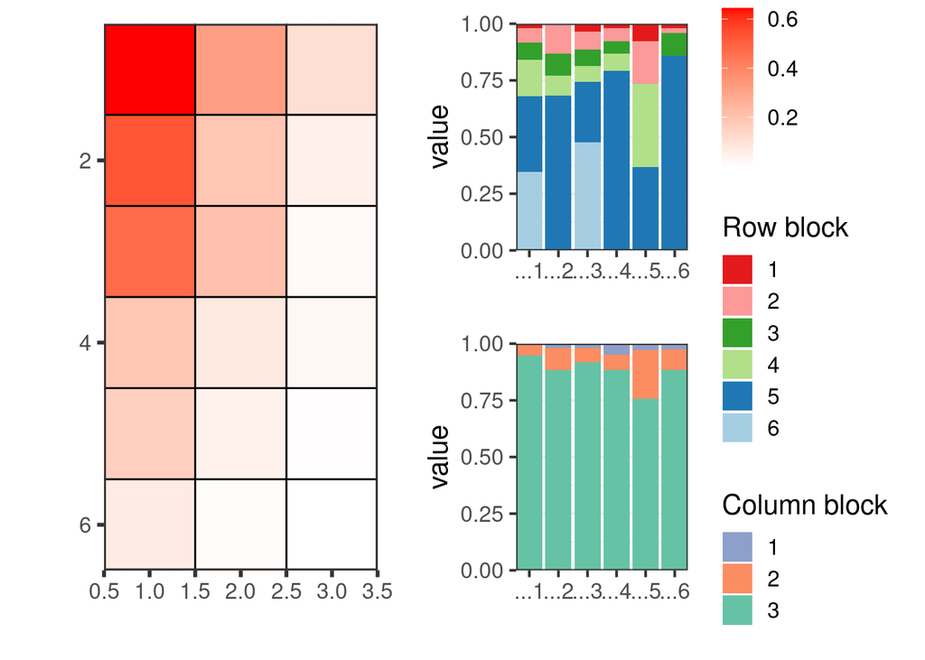

```
## [1] "Kato2000"            "Freitas2006"         "Inoue1990"
## [4] "Souza_cerrado"       "Adedoja2019"         "Baldock2019_Bristol"
##
## Pour la collection 4 du modèle *pirho*
```

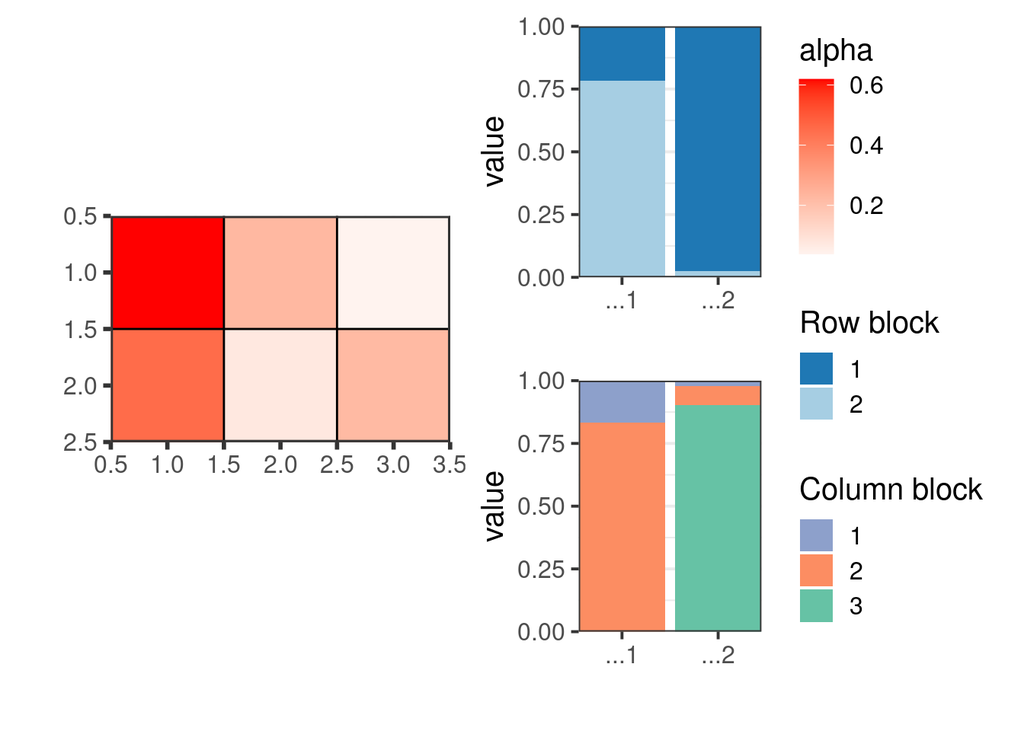

```
## [1] "Aizen2008_Puerto Blest_U+Aizen2008_Puerto Blest_D"
## [2] "LemusJimenez2003"
##
## Pour la collection 5 du modèle *pirho*
```

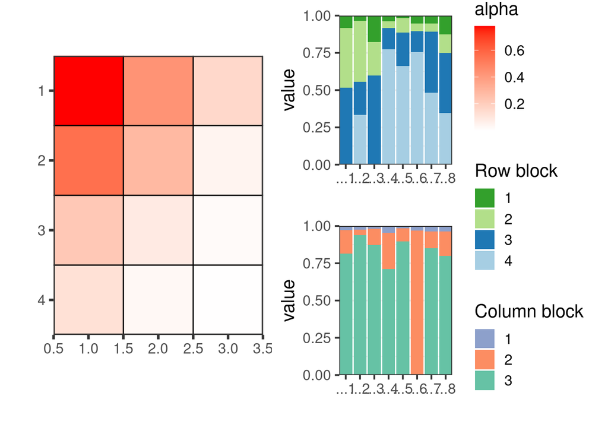

```
## [1] "inouye1988"
## [2] "Junker2013"
## [3] "Kehinde2014_Joostenberg_Conv+Kehinde2014_Joostenberg_Org+Kehinde2014_Joostenberg_Nat+Kehinde2014_Laibach_Conv+Kehinde2014_Laibach_Org+Kehinde2014_Laibach_Nat+Kehinde2014_Spier_Conv+Kehinde2014_Spier_Nat"
## [4] "Watts2016_Chicon+Watts2016_Mantanay+Watts2016_Choquebamba+Watts2016_Huaran+Watts2016_Piscacucho+Watts2016_Poques+Watts2016_Pumamarca+Watts2016_Tiaparo+Watts2016_Yanacocha"
## [5] "Kakutani1990"
## [6] "Fragoso_RA1+Fragoso_RD2"
## [7] "Souza_chaco"
## [8] "Oleques2019"
##
## Pour la collection 6 du modèle *pirho*
```

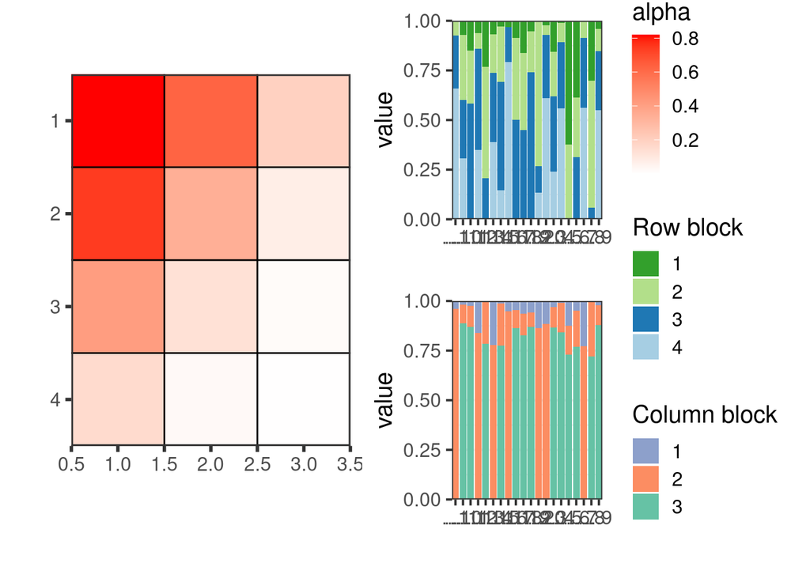

```
##  [1] "medan2002ld"
##  [2] "small1976"
##  [3] "smith-ramirez2005"
##  [4] "Benadi2013_1(950m)+Benadi2013_2(1170m)+Benadi2013_6(2020m)"
##  [5] "Shay2016"
##  [6] "Aizen2008_Cerro Otto_U+Aizen2008_Cerro Otto_D"
##  [7] "Lundgren2005"
##  [8] "Zackenberg"
##  [9] "Carstensen_Gigante+Carstensen_Paulino+Carstensen_Tinkerbell+Carstensen_Midway+Carstensen_Cedro+Carstensen_Elefante+Carstensen_Soizig"
## [10] "Welti_ID+Welti_K1B+Welti_K4A+Welti_4B+Welti_20B+Welti_20C+Welti_N1A+Welti_N1B+Welti_N4A+Welti_N4B+Welti_N20A+Welti_N20B"
## [11] "Bennett2018"
## [12] "CordenizPicanco2018_NatFor"
## [13] "CordenizPicanco2018_ExoFor"
## [14] "CordenizPicanco2018_IntPast"
## [15] "Benadi2018"
## [16] "Villalobos2019"
## [17] "Traveset2013_Santiago"
## [18] "Traveset2013_SantaCruz"
## [19] "Son2019_a1+Son2019_a2+Son2019_a3+Son2019_a4+Son2019_a5+Son2019_a6+Son2019_a7+Son2019_a8+Son2019_F1+Son2019_F2+Son2019_F3+Son2019_F4+Son2019_F5+Son2019_F6+Son2019_F7+Son2019_F8"
## [20] "Sritongchuay2019_near+Sritongchuay2019_far"
##
## Pour la collection 7 du modèle *pirho*
```

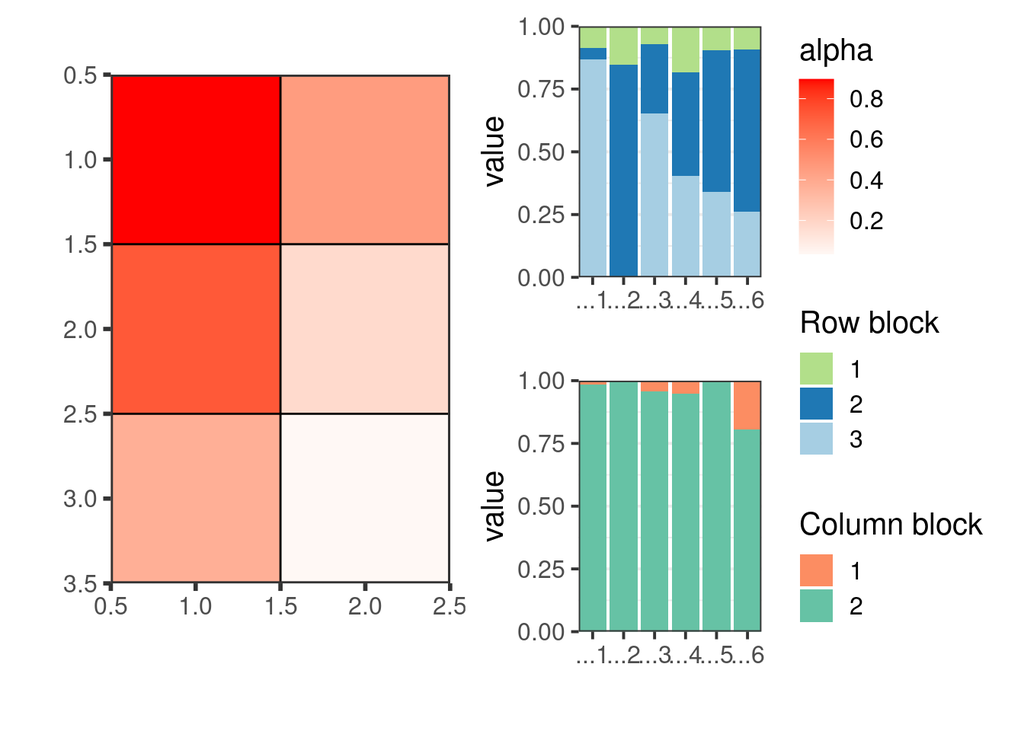

```
## [1] "medan2002rb"
## [2] "olensen2002flo"
## [3] "vazquez2002"
## [4] "Trojelsgaard2015_Gran Canaria"
## [5] "Trojelsgaard2015_Western Sahara"
## [6] "LaraRomero2019_blanca+LaraRomero2019_rajada+LaraRomero2019_refugio+LaraRomero2019_torre"
##
## Pour la collection 8 du modèle *pirho*
```

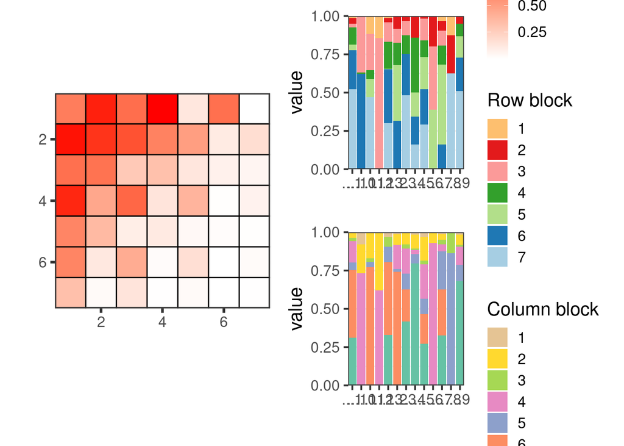

```
##  [1] "Weiner2011"
##  [2] "Kaiser_control+Kaiser_restored"
##  [3] "Gilarranz2014_amarante+Gilarranz2014_barrosa+Gilarranz2014_cincocerros+Gilarranz2014_difuntito+Gilarranz2014_difuntos+Gilarranz2014_elmorro+Gilarranz2014_labrava+Gilarranz2014_lachata+Gilarranz2014_lapaja+Gilarranz2014_piedraalta+Gilarranz2014_vigilancia+Gilarranz2014_volcan"
##  [4] "Kaiser-Bunbury2017_Bernica+Kaiser-Bunbury2017_Casse-dent+Kaiser-Bunbury2017_Copolia+Kaiser-Bunbury2017_La-Reserve+Kaiser-Bunbury2017_Rosebelle+Kaiser-Bunbury2017_Salazie+Kaiser-Bunbury2017_Tea-Plantation+Kaiser-Bunbury2017_Trois-Freres"
##  [5] "Fang2012"
##  [6] "Gibson2006_SG"
##  [7] "Gibson2006_TA1"
##  [8] "Trojelsgaard2015_Fuerteventura"
##  [9] "Pfeiffer_CNE+Pfeiffer_CNM+Pfeiffer_CNT+Pfeiffer_CPB+Pfeiffer_CPM+Pfeiffer_CPR+Pfeiffer_CPS+Pfeiffer_M2+Pfeiffer_RP1+Pfeiffer_RP2+Pfeiffer_LM+Pfeiffer_LO+Pfeiffer_BD+Pfeiffer_BH+Pfeiffer_BS"
## [10] "Biella2019"
## [11] "Nel2017"
## [12] "Ferrero2013"
## [13] "Neli2014"
##
## Pour la collection 9 du modèle *pirho*
```

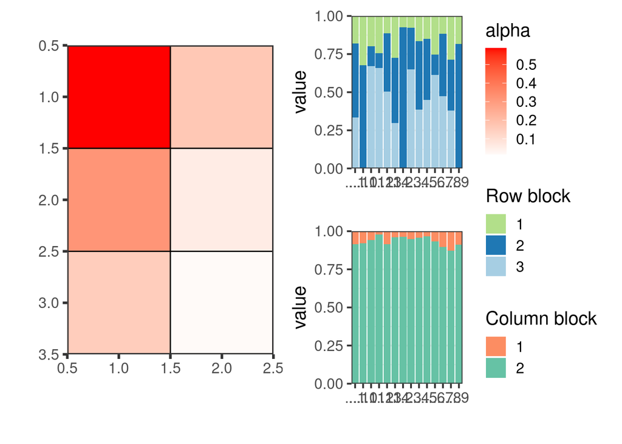

```
##  [1] "eberling1999"
##  [2] "ramirez1992"
##  [3] "Struck1994"
##  [4] "Albrecht2010_49yr+Albrecht2010_63yr+Albrecht2010_84yr+Albrecht2010_109yr+Albrecht2010_130yr"
##  [5] "Devoto2005_PP+Devoto2005_AP"
##  [6] "Devoto2005_VT"
##  [7] "Gibson2006_TA2"
##  [8] "MonteroCastano2017_Albufera+MonteroCastano2017_Llimpa+MonteroCastano2017_Tirant"
##  [9] "Yoshihara2008"
## [10] "PopicThesis"
## [11] "Orford_B1+Orford_B2+Orford_B3+Orford_B4+Orford_B5+Orford_B10"
## [12] "Souza_vereda"
## [13] "Adedoja2018b_baseZone+Adedoja2018b_MidZone+Adedoja2018b_HighZone+Adedoja2018b_PeakZone"
## [14] "Hackett2019_NZ_salt_marsh+Hackett2019_NZ_sand_dune+Hackett2019_NZ_scrub_coprosma"
##
## Pour la collection 10 du modèle *pirho*
```

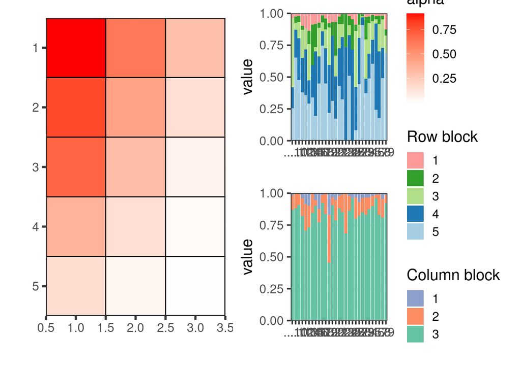

```
##  [1] "herrera1988"
##  [2] "Burkle2013"
##  [3] "bartomeus2008"
##  [4] "Olito-Fox2014"
##  [5] "Benadi2013_4(1700m)+Benadi2013_5(1800m)"
##  [6] "Baldock2011_TB+Baldock2011_JN"
##  [7] "Chamberlain_HLU+Chamberlain_HLG+Chamberlain_OKU+Chamberlain_OKG+Chamberlain_WLU+Chamberlain_WLG+Chamberlain_SOU+Chamberlain_SOG"
##  [8] "Chamberlain_Site1+Chamberlain_Site2+Chamberlain_Site3+Chamberlain_Site4+Chamberlain_Site5+Chamberlain_Site6"
##  [9] "Devoto2005_LQ"
## [10] "Devoto2005_LT+Devoto2005_LH"
## [11] "Devoto2005_LL+Devoto2005_CT"
## [12] "Dupont2009_IsenBjerg+Dupont2009_Other"
## [13] "Gibson2006_GA1"
## [14] "LaraRomero2016_pe?alara_EP+LaraRomero2016_pe?alara_PA+LaraRomero2016_nevero_EP+LaraRomero2016_nevero_PA"
## [15] "Marrero2013"
```

[output cut: 16 more lines]

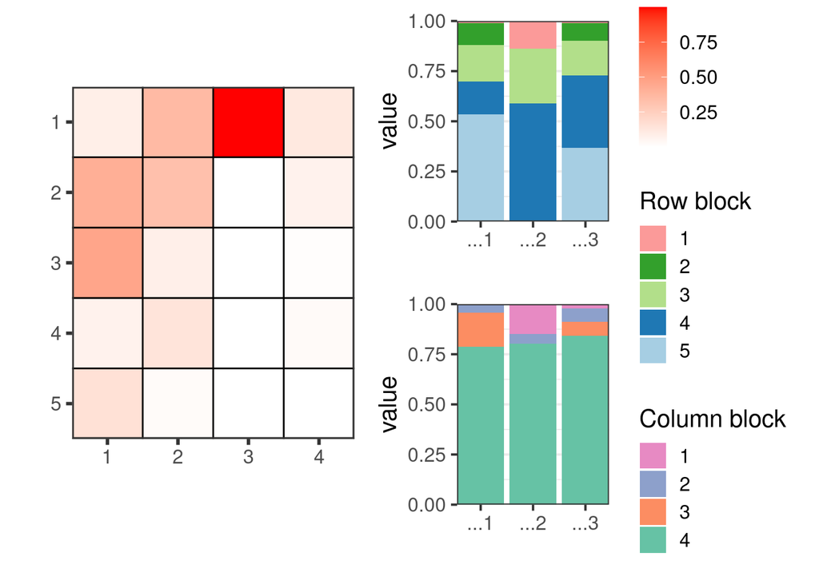

```
## [1] "kato1990"    "ramirez1989" "Kato1993"
##
## Pour la collection 12 du modèle *pirho*
```

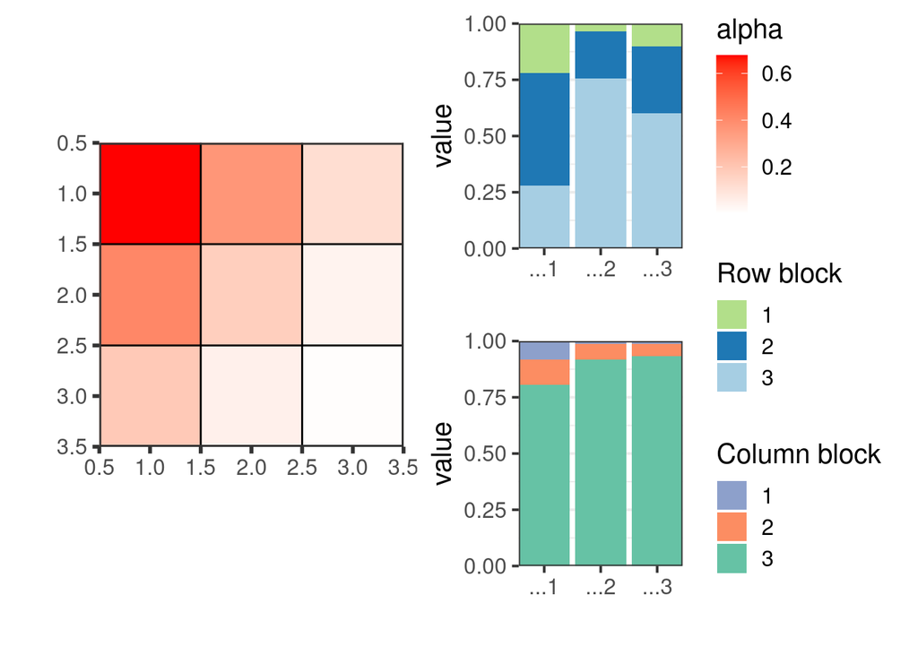

```
## [1] "Chamberlain_cr1+Chamberlain_cr2+Chamberlain_fs1+Chamberlain_fs2+Chamberlain_go1+Chamberlain_go2+Chamberlain_mm1+Chamberlain_mm2+Chamberlain_mz1+Chamberlain_mz2+Chamberlain_sm1+Chamberlain_sm2"
## [2] "Dattilo2016"
## [3] "KatoMiura1996"
##
## Pour la collection 13 du modèle *pirho*
```

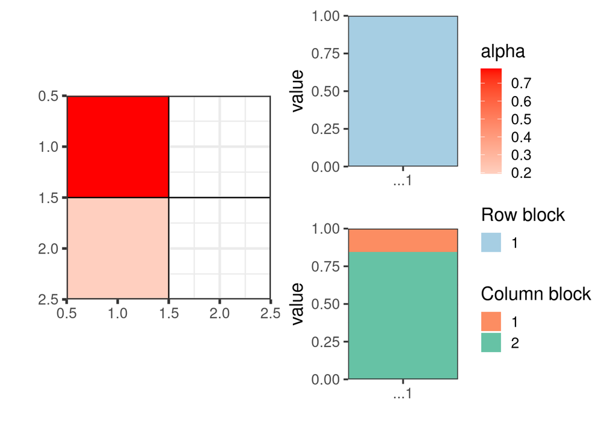

```
## [1] "olensen2002aig"
##
## Pour la collection 14 du modèle *pirho*
```

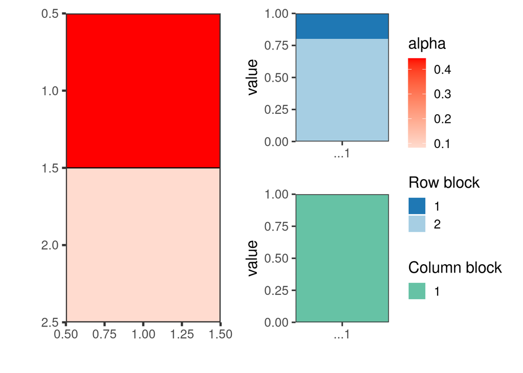

```
## [1] "Trojelsgaard2015_El Hierro"
##
## Pour la collection 15 du modèle *pirho*
```

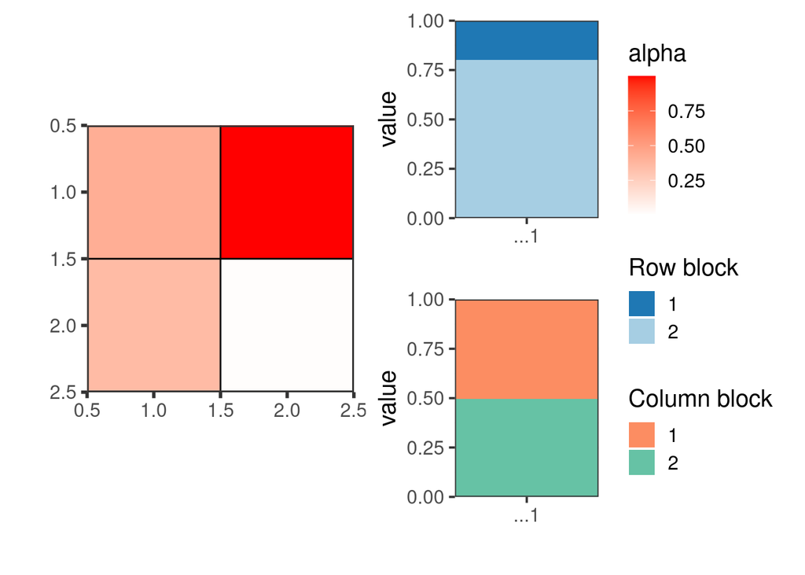

```
## [1] "Gibson2006_GA2"
```

Et voici donc les valeurs numériques pour les $\alpha$ (paramètres de connectivité).

Pour la collection 1 :
$$\begin{bmatrix} 0.00202909614612981 &0.00767288256337502 &0.379081193219286 &0.168001491426483 &0.02566761269436 &0.0304703724100137 &0.150268409136461 \\0.344641784974602 &0.516813876870725 &0.0970476926955427 &0.596100304448219 &0.00484412982135923 &0.0197903302740868 &0.0480521766443602 \\0.614320476435997 &0.310022152244603 &0.161618204897288 &0.0808169984880069 &0.0519107326464702 &0.12473929491004 &0.373069940794492 \\0.0392281997593451 &0.270974097466418 &0.00761350237534822 &0.00238454705106516 &0.00800450110599669 &0.21697958007006 &0.0516297241600399 \\0.0249554953349721 &0.00526857644051425 &0.0081130421907864 &0.927760248700897 &0.36470928317312 &0.00872017161768662 &0.121268504260932 \\1.16415406032088e-09 &0.0120437213313504 &0.0426359574985826 &0.163556635406758 &0.0114639884378546 &0.106351156607967 &0.00526600122089999 \\ \end{bmatrix}$$
Pour la collection 2 :
$$\begin{bmatrix} 0.0519152954685512 &0.204549675762901 \\0.23085078996383 &0.659399313162326 \\ \end{bmatrix}$$
Pour la collection 3 :
$$\begin{bmatrix} 0.00100713371975475 &0.0662883200832048 &0.0139490549751477 &0.00555103558134077 &0.15792737170378 &0.0456339843757953 \\0.106459187722155 &0.644704487427368 &0.321467859673983 &0.0492555865057761 &0.530738166802705 &0.191808592350379 \\0.0268663366433685 &0.187612704230878 &0.0721799132760322 &0.0193366367519497 &0.470231422653708 &0.207514757709914 \\ \end{bmatrix}$$
Pour la collection 4 :
$$\begin{bmatrix} 0.619239702054223 &0.227964538354872 \\0.0382223068766231 &0.453232848976364 \\0.0734978642052861 &0.222863339918335 \\ \end{bmatrix}$$
Pour la collection 5 :
$$\begin{bmatrix} 0.0192747245601601 &0.0848781765141652 &0.22215957432665 &0.0433788755769414 \\0.285318803512983 &0.557681891779736 &0.0040083657575006 &0.0296996782446064 \\0.124344925081453 &0.158281608477558 &0.431385402596545 &0.779708610886029 \\ \end{bmatrix}$$
Pour la collection 6 :
$$\begin{bmatrix} 0.00340787695878703 &0.025603995944106 &0.156615743441505 &0.0192871463177438 \\0.128500751581139 &0.414375949602551 &0.0739815942840563 &0.339332417826404 \\0.742745323569746 &0.195875534515737 &0.62612044000989 &0.819534320080074 \\ \end{bmatrix}$$
Pour la collection 7 :
$$\begin{bmatrix} 0.0348346916565029 &0.371261696541829 &0.455146168384763 \\0.895957330987341 &0.171605194016587 &0.723881166139245 \\ \end{bmatrix}$$
Pour la collection 8 :
$$\begin{bmatrix} 0.0504411252316361 &0.32317354127639 &0.130242069487431 &0.0725864422882952 &0.713762529306326 &0.702042168836911 &0.28126855348764 \\0.00768281772055428 &0.109661531362108 &0.0355775403832748 &0.0158369575937727 &0.619684098960405 &0.359424166087823 &0.0901431495080115 \\0.172718868122429 &0.635426115779892 &0.50000066916226 &0.106826941485551 &0.985677592413377 &0.92664081252215 &0.83516224590246 \\0.00293334088444442 &0.0049306288141211 &0.0277381700574665 &0.000506089565090073 &0.330868937968233 &0.0280636703275782 &0.14017446175747 \\0.000132992885392135 &0.999999887736257 &0.128107237028513 &0.71354858938449 &0.65567198188683 &0.96784691235524 &0.721541448952102 \\0.0221906012438483 &0.0205095587546685 &0.166730473085899 &0.00168167638082958 &0.621767901332703 &0.120551549529913 &0.431356854711563 \\0.0667312868000454 &0.139304848355425 &0.387216377556931 &0.00755063263557269 &0.955318874801402 &0.4552585471734 &0.750339727515674 \\ \end{bmatrix}$$
Pour la collection 9 :
$$\begin{bmatrix} 0.016449094525925 &0.154020394948056 &0.0588049056608142 \\0.319601844629981 &0.170109302893893 &0.588788110484065 \\ \end{bmatrix}$$
Pour la collection 10 :
$$\begin{bmatrix} 0.00636279975225225 &0.0450612422669826 &0.159877796198325 &0.0291774521311737 &0.154711872287249 \\0.358283865540322 &0.154888876319754 &0.439648383351604 &0.787430541357749 &0.0675314863597621 \\0.315146610695875 &0.695924954621697 &0.30034721579476 &0.620360576313872 &0.912869440329063 \\ \end{bmatrix}$$
Pour la collection 11 :
$$\begin{bmatrix} 0.117630327856727 &0.999999900692361 &0.0863535903160425 &0.357952019298409 &0.0696471158924184 \\2.85343790481127e-06 &0.414331597401482 &0.325863128965866 &0.00158149838252738 &6.83009449460006e-11 \\0.159439916023688 &0.02129013828089 &0.025375801371388 &5.18754205295449e-08 &0.0699073415878291 \\0.140813287635949 &0.0105021226558031 &3.69290660352557e-09 &0.464964746685131 &0.0859483053500175 \\ \end{bmatrix}$$
Pour la collection 12 :
$$\begin{bmatrix} 0.00757989820229492 &0.189988354506428 &0.0523974791069118 \\0.0414729261203306 &0.413635786901603 &0.170149987579423 \\0.118248430354353 &0.677540115109252 &0.366048271682253 \\ \end{bmatrix}$$
Pour la collection 13 :
$$\begin{bmatrix} 0.194344344371523 \\0.781423184439111 \\ \end{bmatrix}$$
Pour la collection 14 :
$$\begin{bmatrix} 0.0833332652626414 &0.44444157833105 \\ \end{bmatrix}$$
Pour la collection 15 :
$$\begin{bmatrix} 0.010720622388661 &0.352585288976298 \\0.999999995453121 &0.418964316798331 \\ \end{bmatrix}$$